# Вариант 5 (15)

BXP Boston Properties Real Estate

C Citigroup Financials

CAG Conagra Brands Consumer Staples

CAH Cardinal Health Health Care

CARR Carrier Global Industrials

CAT Caterpillar Industrials

CB Chubb Financials

CBOE Cboe Global Markets Financials

CBRE CBRE Real Estate

CCI Crown Castle Real Estate

```python
%matplotlib inline
import matplotlib.pyplot as plt
import numpy as np
import pandas as pd
import yfinance as yf
import time
```

# Данные

Загружаем цены закрытия каждого актива за весь 2021 год и сразу нормируем их

```python
def get_normalized_asset(company, start_day, end_day):
    df = pd.DataFrame()
    data = yf.Ticker(company).history(start=start_day, end=end_day) #period="1y"
    df.index = data.index
    df[company] = (data.Close-data.Close.mean()) / data.Close.std()
    return df
```

```python
start_day = '2021-01-01'
end_day = '2022-01-01'
assetList = ['BXP', 'C', 'CAG', 'CAH', 'CARR', 'CAT', 'CB', 'CBOE', 'CBRE', 'CCI']
```

```python
RatesData = get_normalized_asset(assetList[0], start_day, end_day)
for i in range(1, len(assetList)):
    asset = get_normalized_asset(assetList[i], start_day, end_day)
    RatesData = pd.concat([RatesData, asset], axis=1)
RatesData
```

| Date | BXP | C | CAG | CAH | CARR | CAT | CB | CBOE | CBRE | CCI |
| --- | --- | --- | --- | --- | --- | --- | --- | --- | --- | --- |
| 2021-01-04 00:00:00-05:00 | -2.183044 | -2.107988 | 0.282059 | -0.497686 | -1.616060 | -2.122851 | -1.849251 | -1.744534 | -2.284006 | -1.807460 |
| 2021-01-05 00:00:00-05:00 | -2.259905 | -1.790091 | 0.057658 | -0.449226 | -1.483855 | -2.024692 | -1.840125 | -1.749242 | -2.290399 | -1.769555 |
| 2021-01-06 00:00:00-05:00 | -2.119875 | -1.066671 | 0.146377 | 0.045575 | -1.177312 | -1.351417 | -1.298034 | -1.520103 | -2.195300 | -2.029297 |
| 2021-01-07 00:00:00-05:00 | -2.243058 | -0.909762 | -0.871246 | 0.364388 | -1.026219 | -1.327042 | -1.383188 | -1.416519 | -2.124175 | -1.965915 |
| 2021-01-08 00:00:00-05:00 | -2.265168 | -1.042217 | -0.719908 | 0.262369 | -1.084332 | -1.325065 | -1.418161 | -1.258005 | -2.033071 | -1.865871 |
| ... | ... | ... | ... | ... | ... | ... | ... | ... | ... | ... |
| 2021-12-27 00:00:00-05:00 | 0.787687 | -1.626653 | -0.452980 | -0.553228 | 0.862920 | -0.242599 | 1.741456 | 1.173859 | 1.575117 | 1.667516 |
| 2021-12-28 00:00:00-05:00 | 0.723887 | -1.632954 | -0.172184 | -0.458992 | 0.855580 | -0.226461 | 1.737587 | 1.202893 | 1.569523 | 1.766736 |
| 2021-12-29 00:00:00-05:00 | 0.753084 | -1.649754 | -0.204581 | -0.372610 | 0.893750 | -0.178709 | 1.809566 | 1.111080 | 1.638250 | 1.830747 |
| 2021-12-30 00:00:00-05:00 | 0.875230 | -1.672853 | -0.204581 | -0.341197 | 0.865856 | -0.262778 | 1.712821 | 1.131483 | 1.632656 | 1.870435 |
| 2021-12-31 00:00:00-05:00 | 0.816338 | -1.681254 | -0.058781 | -0.391141 | 0.967154 | -0.218390 | 1.728298 | 1.220941 | 1.632656 | 1.922927 |

252 rows × 10 columns

# Метод главных компонент

Применяем к данным метод главных компонент

```python
from sklearn.decomposition import PCA
from sklearn import linear_model

pca = PCA(svd_solver='full')
pca.fit(RatesData)
print('Explained variance by factors:\n', pca.explained_variance_.round(1))
```

```
Explained variance by factors:
 [5.4 3.  0.8 0.3 0.2 0.1 0.1 0.  0.  0. ]
```

## Построить график важности каждой главной компоненты

```
<BarContainer object of 10 artists>
```

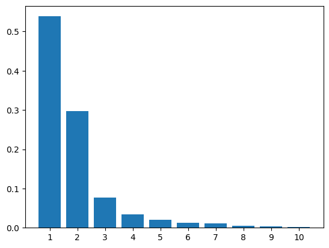

```python
plt.bar(np.arange(1, 11), pca.explained_variance_ratio_, tick_label=np.arange(1, 11))
```

## Получить 3 главных копоненты и три соответствующих вектора факторных нагрузок

### Нагрузки

```python
pca.components_
```

```
array([[-3.56967856e-01, -3.61682372e-02,  2.25361369e-01,
         2.40505999e-01, -4.10028254e-01,  6.93239559e-02,
        -3.87858024e-01, -4.22997301e-01, -4.12484991e-01,
        -3.00335670e-01],
       [ 2.73516736e-01,  4.71487920e-01,  4.50462392e-01,
         3.79750924e-01,  7.20763514e-03,  5.28677505e-01,
        -3.67987390e-02,  2.20293965e-02,  9.78402940e-02,
         2.54551738e-01],
       [ 7.19405302e-02, -5.30717175e-01,  2.40076231e-03,
         4.59861291e-01,  1.30120903e-01, -1.90227385e-01,
        -2.90250846e-01,  1.77126671e-02, -8.74900156e-02,
         5.96953908e-01],
       [-1.47770745e-01, -5.57788352e-01,  3.33515849e-01,
        -1.95730328e-01, -3.26491553e-01,  3.80492463e-01,
         4.65774064e-01, -6.49944201e-02,  1.76159800e-01,
         1.17980939e-01],
       [-3.42249193e-01, -4.10389870e-02, -5.06728207e-01,
         5.08257122e-01,  2.80051382e-01,  3.79588058e-01,
         3.30405961e-01, -9.26667346e-02,  5.93884835e-03,
        -1.60549530e-01],
       [-2.15315556e-01,  1.18057644e-01, -2.82159681e-01,
        -5.04933958e-01,  9.45208948e-02,  4.30014510e-01,
        -2.21242107e-01, -8.03260311e-02, -3.53665277e-01,
         4.80419680e-01],
       [ 6.54948846e-01, -1.97892881e-01, -4.61008592e-01,
         2.76628819e-02, -4.15929115e-01,  2.92960078e-01,
        -1.68962066e-01, -1.63911677e-02, -1.95214731e-02,
        -1.74830447e-01],
       [ 2.67398297e-01,  1.96762039e-01, -5.80238732e-02,
         5.20836718e-02, -1.10996372e-01, -2.94215619e-01,
         5.58552736e-01, -5.00272243e-01, -3.92198516e-01,
         2.62196862e-01],
       [ 3.32624489e-02, -5.24601448e-03, -5.86188333e-02,
        -1.18266471e-01,  1.81289809e-01, -2.67017942e-04,
        -2.19482877e-01, -7.26957092e-01,  6.08050206e-01,
         4.70371762e-02],
       [-3.25099035e-01,  3.00126999e-01, -2.81669809e-01,
         1.31965249e-01, -6.34626270e-01, -1.82606767e-01,
         1.42384074e-02,  1.48334013e-01,  3.64082979e-01,
         3.41502317e-01]])
```

```python
pca_loadings = pd.DataFrame(pca.components_)
pca_loadings = pca_loadings.transpose()
pca_loadings.columns = ['pca.l{}'.format(i+1) for i in range(pca.n_components_)]
pca_loadings = pca_loadings[['pca.l1', 'pca.l2', 'pca.l3']].copy()
pca_loadings
```

|  | pca.l1 | pca.l2 | pca.l3 |
| --- | --- | --- | --- |
| 0 | -0.356968 | 0.273517 | 0.071941 |
| 1 | -0.036168 | 0.471488 | -0.530717 |
| 2 | 0.225361 | 0.450462 | 0.002401 |
| 3 | 0.240506 | 0.379751 | 0.459861 |
| 4 | -0.410028 | 0.007208 | 0.130121 |
| 5 | 0.069324 | 0.528678 | -0.190227 |
| 6 | -0.387858 | -0.036799 | -0.290251 |
| 7 | -0.422997 | 0.022029 | 0.017713 |
| 8 | -0.412485 | 0.097840 | -0.087490 |
| 9 | -0.300336 | 0.254552 | 0.596954 |

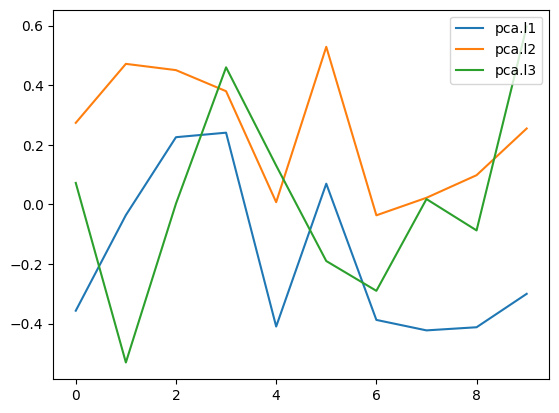

```python
pca_loadings.plot()
```

### Факторы

```python
pca_factors = pd.DataFrame(pca.transform(RatesData),
                           columns=['pca.f{}'.format(i+1) for i in range(pca.n_components_)],
                           index=RatesData.index)[['pca.f1', 'pca.f2','pca.f3']].reset_index().drop('Date', axis=1)
```

```python
pca_factors
```

|  | pca.f1 | pca.f2 | pca.f3 |
| --- | --- | --- | --- |
| 0 | 4.254996 | -3.440823 | 0.553751 |
| 1 | 4.174321 | -3.333211 | 0.420240 |
| 2 | 3.889752 | -2.439519 | -0.130711 |
| 3 | 3.655969 | -2.694079 | -0.005492 |
| 4 | 3.581074 | -2.693362 | 0.073434 |
| ... | ... | ... | ... |
| 247 | -3.150627 | -0.547323 | 1.195853 |
| 248 | -3.075824 | -0.371500 | 1.295948 |
| 249 | -3.121160 | -0.309357 | 1.352174 |
| 250 | -3.131482 | -0.305992 | 1.452652 |
| 251 | -3.187377 | -0.240390 | 1.463421 |

252 rows × 3 columns

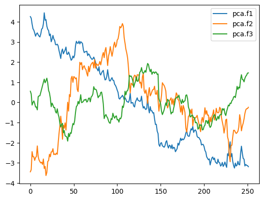

```python
pca_factors.plot()
```

# Автоэнкодер

```python
from tensorflow.keras.layers import Dense, Input
from tensorflow.keras.models import Model
from tensorflow.keras.optimizers import Adam
```

## Создать нейронную сеть автоэнкодера с входом из нормированных акций, 3 нейронами на внутренним слое и с выходом, как и размерность входа

Количество нейронов на внутреннем слое

```python
encoding_dim = 3
```

Строим модель

```python
# encode:
input_layer = Input(shape=(RatesData.shape[1],))
encoded_layer = Dense(encoding_dim, use_bias=False, activation=None)
encoded = encoded_layer(input_layer)

# decode:
input_encoded = Input((encoding_dim,))
decoded_layer = Dense(RatesData.shape[1], use_bias=False, activation=None)
decoded = decoded_layer(input_encoded)

# models:
encoder = Model(input_layer, encoded, name="encoder")
decoder = Model(input_encoded, decoded, name="decoder")
autoencoder = Model(input_layer, decoder(encoder(input_layer)), name="autoencoder")

lr = 0.0005 # learning rate, defaults to 0.001
autoencoder.compile(optimizer=Adam(lr), loss='mse')

autoencoder.summary()
```

```
Model: "autoencoder"
_________________________________________________________________
 Layer (type)                Output Shape              Param #
=================================================================
 input_1 (InputLayer)        [(None, 10)]              0

 encoder (Functional)        (None, 3)                 30

 decoder (Functional)        (None, 10)                30

=================================================================
Total params: 60
Trainable params: 60
Non-trainable params: 0
_________________________________________________________________
```

Обучаем модель

```python
autoencoder.fit(RatesData, RatesData,
                verbose=0,
                epochs=6000,
                batch_size=RatesData.shape[0])
```

```
<keras.callbacks.History at 0x7f886c264e20>
```

## Постройте коды 3 факторов до вращения

```python
encoded_rates = pd.DataFrame(encoder.predict(RatesData), index=RatesData.index, columns=['ae.f1', 'ae.f2','ae.f3'])
encoded_rates
```

| Date | ae.f1 | ae.f2 | ae.f3 |
| --- | --- | --- | --- |
| 2021-01-04 00:00:00-05:00 | -0.836536 | -5.472034 | -1.007955 |
| 2021-01-05 00:00:00-05:00 | -0.912921 | -5.295865 | -1.013797 |
| 2021-01-06 00:00:00-05:00 | -1.512191 | -4.615172 | -0.607645 |
| 2021-01-07 00:00:00-05:00 | -1.102919 | -4.375674 | -0.961237 |
| 2021-01-08 00:00:00-05:00 | -0.997236 | -4.329906 | -0.972155 |
| ... | ... | ... | ... |
| 2021-12-27 00:00:00-05:00 | 3.326185 | 3.164395 | -1.579622 |
| 2021-12-28 00:00:00-05:00 | 3.219567 | 3.000293 | -1.292115 |
| 2021-12-29 00:00:00-05:00 | 3.244119 | 3.025303 | -1.207589 |
| 2021-12-30 00:00:00-05:00 | 3.299270 | 2.968221 | -1.136266 |
| 2021-12-31 00:00:00-05:00 | 3.314239 | 3.034846 | -1.110294 |

252 rows × 3 columns

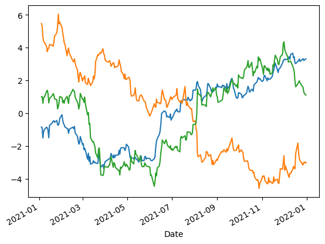

```python
encoded_f1_plot = encoded_rates['ae.f1']
encoded_f2_plot = -encoded_rates['ae.f2']
encoded_f3_plot = -encoded_rates['ae.f3']
encoded_f1_plot.plot()
encoded_f2_plot.plot()
encoded_f3_plot.plot()
plt.show()
```

## Вычислите соответствующие факторные нагрузки через регрессионную модель

```
Autoencoder loadings by regression:
     rega.l1   rega.l2   rega.l3
0  0.108024  0.351538  0.218412
1 -0.565964  0.297375  0.239287
2 -0.434821 -0.293475  0.596786
3 -0.147119 -0.575856  0.785540
4  0.404024  0.513474 -0.233324
5 -0.438741  0.074766  0.398229
6  0.119917  0.591948 -0.346451
7  0.347379  0.492606 -0.301022
8  0.248210  0.657249 -0.252511
9  0.347505 -0.089709  0.596613
```

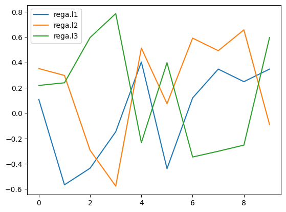

```python
regr = linear_model.LinearRegression()

rfa1 = regr.fit(RatesData, encoded_rates['ae.f1'])
rega_l1 = pd.DataFrame({'rega.l1': rfa1.coef_})

rfa2 = regr.fit(RatesData, encoded_rates['ae.f2'])
rega_l2 = pd.DataFrame({'rega.l2': rfa2.coef_})

rfa3 = regr.fit(RatesData, encoded_rates['ae.f3'])
rega_l3 = pd.DataFrame({'rega.l3': rfa3.coef_})

ae_loadings_by_regression = rega_l1.join([rega_l2, rega_l3])
print('Autoencoder loadings by regression: \n', ae_loadings_by_regression)
ae_loadings_by_regression.plot()
```

## Поверните факторы так, чтобы они стали некоррелированными и сравните графически повернутые факторы с факторами PCA

Для этого вычисляем собственные вектора ковариационной матрицы, проецируем на них факторы

```python
eg_vect_factors = np.linalg.eig(encoded_rates.cov())[1]
eg_vect_factors = pd.DataFrame(eg_vect_factors)
eg_vect_factors
```

|  | 0 | 1 | 2 |
| --- | --- | --- | --- |
| 0 | 0.504666 | 0.846280 | -0.170655 |
| 1 | 0.698154 | -0.283786 | 0.657302 |
| 2 | -0.507832 | 0.450861 | 0.734051 |

```python
rotated_factors = pd.DataFrame(np.dot(encoded_rates,eg_vect_factors),
                               columns=['rot.f1','rot.f2','rot.f3'])
rotated_factors
```

|  | rot.f1 | rot.f2 | rot.f3 |
| --- | --- | --- | --- |
| 0 | -3.730622 | 0.390494 | -4.193911 |
| 1 | -3.643211 | 0.273223 | -4.069368 |
| 2 | -3.676670 | -0.243980 | -3.221542 |
| 3 | -3.123353 | -0.125009 | -3.393519 |
| 4 | -3.032521 | -0.053482 | -3.389485 |
| ... | ... | ... | ... |
| 247 | 4.690029 | 1.204682 | 0.352811 |
| 248 | 4.375649 | 1.290649 | 0.474186 |
| 249 | 4.362576 | 1.342439 | 0.548481 |
| 250 | 4.314336 | 1.437467 | 0.553904 |
| 251 | 4.355216 | 1.442938 | 0.614207 |

252 rows × 3 columns

```python
def defineOrder(pca_factors,rot_factors):
    pca_cols = pca_factors.columns
    rot_cols = rot_factors.columns
    ncol = len(pca_cols)
    mylist = []
    alllist = []
    i = 0

    for pca_col in pca_cols:
        pcaf =pca_factors[pca_col]
        j = 0
        for rot_col in rot_cols:
            rotf = rot_factors[rot_col]
            cor = np.corrcoef(pcaf,rotf)[0,1]
            print(i,j,cor) #abs(cor))
            mylist = []
            mylist.append(i)
            mylist.append(j)
            mylist.append(abs(cor))
            mylist.append(np.sign(cor))
            alllist.append(mylist)
            j = j+1
        i = i +1
    df = pd.DataFrame(alllist,columns = ['col1','col2','value','sign'])
    df = df.sort_values(by=['value'], ascending=False)
    df = df[:ncol]
    df = df.sort_values(by='col1')
    return df
```

```python
norm_factors = pd.DataFrame()

for i in range(3):
    rotated_factors['rot.f'+str(i+1)] = rotated_factors['rot.f'+str(i+1)] / rotated_factors['rot.f'+str(i+1)].std()
    norm_factors['pca.f'+str(i+1)] = pca_factors['pca.f'+str(i+1)] / pca_factors['pca.f'+str(i+1)].std()

orderdf = defineOrder(norm_factors, rotated_factors)
```

```
0 0 -0.9119318026164018
0 1 -0.10955598093935402
0 2 -0.3952856139852304
1 0 -0.3951143475623088
1 1 -0.022072340709844537
1 2 0.9180942830729898
2 0 -0.10880375986936028
2 1 0.9933781016359177
2 2 -0.023558669498857245
```

Сравним попарно факторы из PCA и энкодера, для наглядного сравнения нормализуем факторы и учтём знак коэффициента корреляции между ними

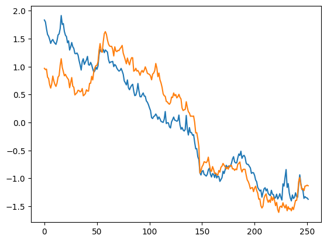

```python
pca_f_plot = pca_factors['pca.f1']/pca_factors['pca.f1'].std()
rot_f_plot = -rotated_factors['rot.f1']/rotated_factors['rot.f1'].std()
pca_f_plot.plot()
rot_f_plot.plot()
plt.show()
```

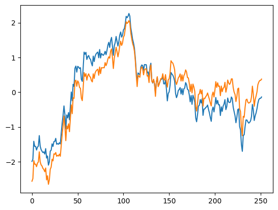

```python
pca_f_plot = pca_factors['pca.f2']/pca_factors['pca.f2'].std()
rot_f_plot = rotated_factors['rot.f3']/rotated_factors['rot.f3'].std()
pca_f_plot.plot()
rot_f_plot.plot()
plt.show()
```

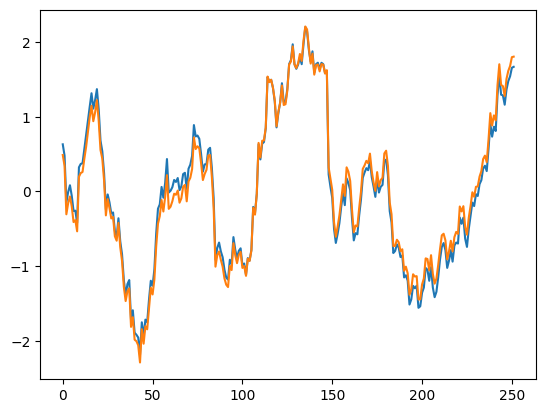

```python
pca_f_plot = pca_factors['pca.f3']/pca_factors['pca.f3'].std()
rot_f_plot = rotated_factors['rot.f2']/rotated_factors['rot.f2'].std()
pca_f_plot.plot()
rot_f_plot.plot()
plt.show()
```

Факторы очень похожи, это видно и из ковариационной матрицы, и из графиков

## Поверните факторные нагрузки и сравните на графиках с нагрузками PCA

Поворачиваем нагрузки аналогично факторам

```python
rotated_loadings = pd.DataFrame(np.dot(ae_loadings_by_regression[['rega.l1','rega.l2','rega.l3']], \
                                       eg_vect_factors),columns=['rot.l1','rot.l2','rot.l3'])
rotated_loadings
```

|  | rot.l1 | rot.l2 | rot.l3 |
| --- | --- | --- | --- |
| 0 | 0.189027 | 0.090131 | 0.372957 |
| 1 | -0.199526 | -0.455469 | 0.467699 |
| 2 | -0.727397 | -0.015629 | 0.319374 |
| 3 | -0.875204 | 0.393086 | 0.223221 |
| 4 | 0.680871 | 0.091004 | 0.097287 |
| 5 | -0.371453 | -0.212969 | 0.416338 |
| 6 | 0.649728 | -0.222705 | 0.114312 |
| 7 | 0.672094 | 0.018467 | 0.043544 |
| 8 | 0.712358 | -0.090310 | 0.204297 |
| 9 | -0.190236 | 0.588535 | 0.319674 |

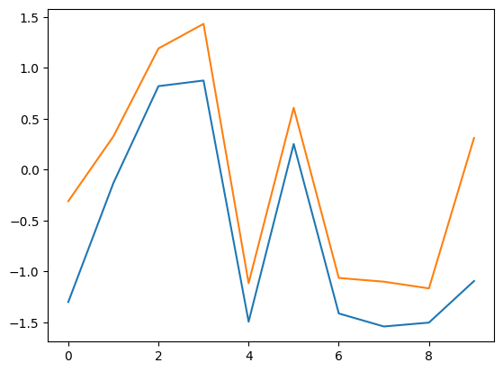

```python
pca_l_plot = pca_loadings['pca.l1'] / pca_loadings['pca.l1'].std()
rot_l_plot = -rotated_loadings['rot.l1'] / rotated_loadings['rot.l1'].std()
pca_l_plot.plot()
rot_l_plot.plot()
plt.show()
```

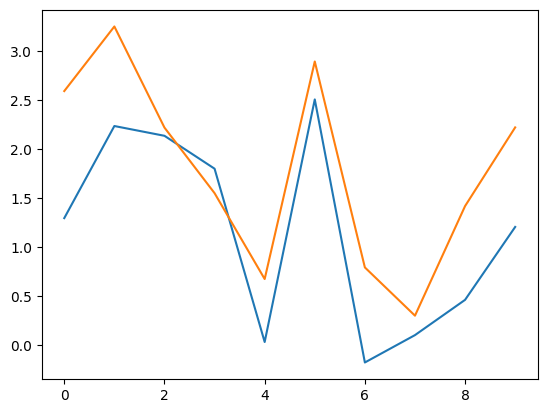

```python
pca_l_plot = pca_loadings['pca.l2'] / pca_loadings['pca.l2'].std()
rot_l_plot = rotated_loadings['rot.l3'] / rotated_loadings['rot.l3'].std()
pca_l_plot.plot()
rot_l_plot.plot()
plt.show()
```

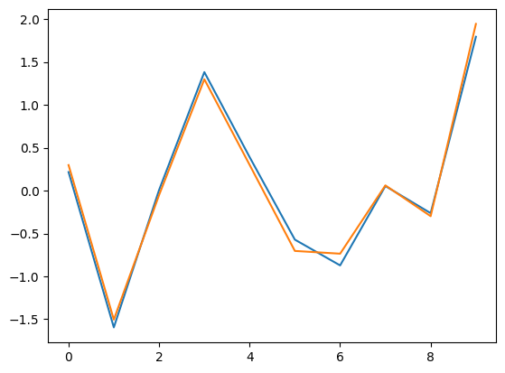

```python
pca_l_plot = pca_loadings['pca.l3'] / pca_loadings['pca.l3'].std()
rot_l_plot = rotated_loadings['rot.l2'] / rotated_loadings['rot.l2'].std()
pca_l_plot.plot()
rot_l_plot.plot()
plt.show()
```

Нагрузки, как и факторы, очень похожи